# Pruning & Rooting Phylogenetic Trees with ggTree

Jordan

2025-03-31

# Goals

## Outputs

# Before you start

## Timing of this script

Let’s record how long this file took to run on the class server, which we will record at the end of the script.

```r
# What time did we start running this script?
start_time <- Sys.time()
```

## Set my seed

```r
# Any number can be chosen
set.seed(238428)
```

## Load Packages

```r
#BiocManager::install("phylobase")

pacman::p_load(tidyverse, phyloseq, ggtree, phytools, tidytree, phylobase,
               install = FALSE)
```

## 1. Load Data files

```r
# Preprocessed phyloseq object
load("data/03_PreProcessing/raw_preprocessed_physeq.RData")

# Inspect the phyloseq object
raw_preprocessed_physeq
```

```
## phyloseq-class experiment-level object
## otu_table()   OTU Table:         [ 6632 taxa and 44 samples ]
## sample_data() Sample Data:       [ 44 samples by 38 sample variables ]
## tax_table()   Taxonomy Table:    [ 6632 taxa by 9 taxonomic ranks ]
```

```r
# Load in the tree!
unrooted_tree <- read.tree("data/04_PhylogeneticTree/ASVs_unrooted.tree")

# Take a look at the tree
unrooted_tree
```

```
##
## Phylogenetic tree with 6632 tips and 6630 internal nodes.
##
## Tip labels:
##   ASV_4279, ASV_4660, ASV_2990, ASV_6253, ASV_4167, ASV_5434, ...
## Node labels:
##   , 0.953, 0.801, 0.775, 0.998, 0.977, ...
##
## Unrooted; includes branch length(s).
```

```r
str(unrooted_tree)
```

```
## List of 5
##  $ edge       : int [1:13261, 1:2] 6633 6634 6635 6636 6637 6637 6636 6638 6639 6640 ...
##  $ edge.length: num [1:13261] 0.03487 0.01359 0.02403 0.11631 0.00676 ...
##  $ Nnode      : int 6630
##  $ node.label : chr [1:6630] "" "0.953" "0.801" "0.775" ...
##  $ tip.label  : chr [1:6632] "ASV_4279" "ASV_4660" "ASV_2990" "ASV_6253" ...
##  - attr(*, "class")= chr "phylo"
##  - attr(*, "order")= chr "cladewise"
```

# 2. Merge Unrooted Tree & `raw_preprocessed_physeq`

Now that we’ve loaded in both our `raw_preprocessed_physeq` and the unrooted tree, let’s merge them into one phyloseq object that can be used to plot the tree with ggtree.

```r
# Intuition check
stopifnot(ntaxa(raw_preprocessed_physeq) == ntaxa(unrooted_tree))
# No news is good news!

# Merge the tree with the phyloseq object
unrooted_physeq <-
  merge_phyloseq(raw_preprocessed_physeq, unrooted_tree)

# Let's take a look!
unrooted_physeq
```

```
## phyloseq-class experiment-level object
## otu_table()   OTU Table:         [ 6632 taxa and 44 samples ]
## sample_data() Sample Data:       [ 44 samples by 38 sample variables ]
## tax_table()   Taxonomy Table:    [ 6632 taxa by 9 taxonomic ranks ]
## phy_tree()    Phylogenetic Tree: [ 6632 tips and 6630 internal nodes ]
```

# 3. Visualize and inspect tree with [ggtree](https://besjournals.onlinelibrary.wiley.com/doi/full/10.1111/2041-210X.12628).

Now, let’s take a look

## Kingdom Level Tree

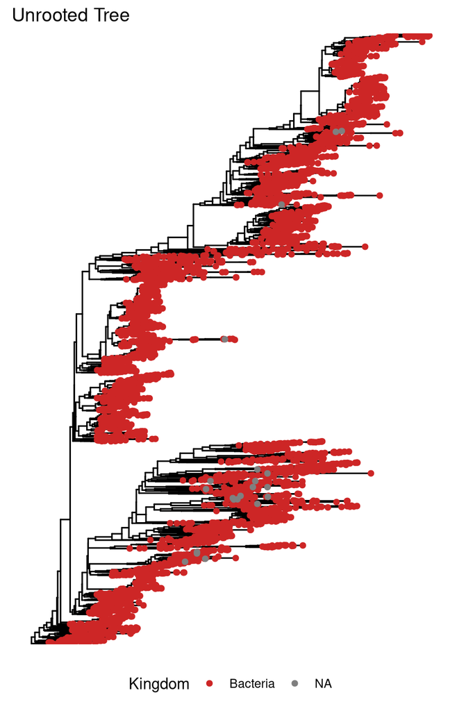

```r
# Make a basic tree with the domains
kingdom_tree <-
  ggtree(unrooted_physeq) +
  # color tips by kingdom
  geom_tippoint(mapping = aes(color = Kingdom)) +
  # add a title
  labs(title = "Unrooted Tree") +
  scale_color_manual(values = c("firebrick3", "cornflowerblue", "grey")) +
  # Move the legend to the bottom of the tree
  theme(legend.position = "bottom")

# Look at it
kingdom_tree
```

```r
# Check if tree is rooted
is.rooted(unrooted_tree) # should be TRUE
```

```
## [1] FALSE
```

# 4. Long Branches?

Now, let’s think about the quality of our tree. Evaluate that kingdom tree above…

It looks like we didn’t sequence Archaea, probably because the PCR primers include 341F. There seem to be a couple long branches that I will have to inspect later. Other than those, the tree looks clean. The branch lengths look proportional throughout.

Before we move onto rooting, this is where we need to assess if we have any long and wonky branches!

## 4a. Evaluate Long Branches

This part will get a little manual, however, this is an important step along the way to ensure that we are feeling certain that our data quality is good.

### Kingdom Tree with Node Labels

Let’s put labels on our tree so we have a bit more flexibility

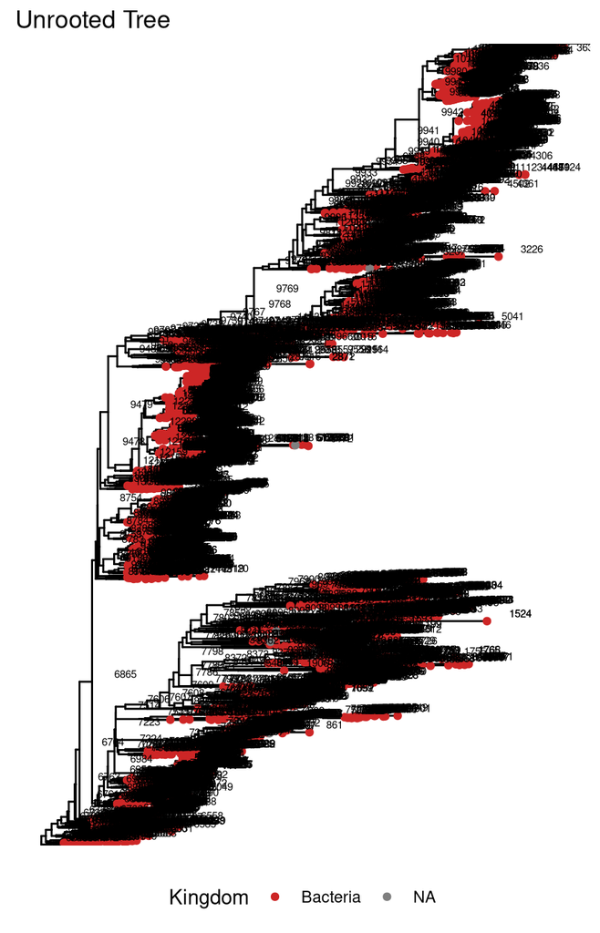

```r
kingdom_node_tree <-
  kingdom_tree +
  # Add the node label
  geom_text(aes(label=node), hjust= -1, vjust = -0.5, size = 2)

# Plot the tree
kingdom_node_tree
```

In the phylogeny above, it looks like **node #1524, #3226** are quite long, and the clade with **#12810**.

### Evaluate node #3226

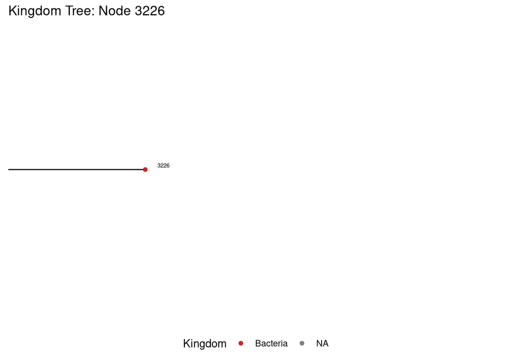

```r
# View a specific clade
# Zoom in on node that looks potentially suspicious
viewClade(kingdom_node_tree +
          labs(title = "Kingdom Tree: Node 3226"),
          node = 3226)
```

```r
# This plot is too zoomed in! Let's try to zoom out by looking at ancestors
# Lets see its ancestors, which will tell us each node as it steps up.
# It's ideal to look a couple nodes up but not too far!
tidytree::ancestor(unrooted_tree, 3226) # The input is the TREE, not phyloseq!!
```

```
##  [1] 9875 9868 9866 9861 9860 9850 9849 9848 9847 9846 9842 9805 9796 9795 9773
## [16] 9772 9771 9770 9769 9768 9767 9740 9739 9738 9737 9718 9707 9690 9551 9480
## [31] 9479 9478 8754 8753 8746 6865 6764 6763 6761 6739 6738 6737 6702 6701 6648
## [46] 6633
```

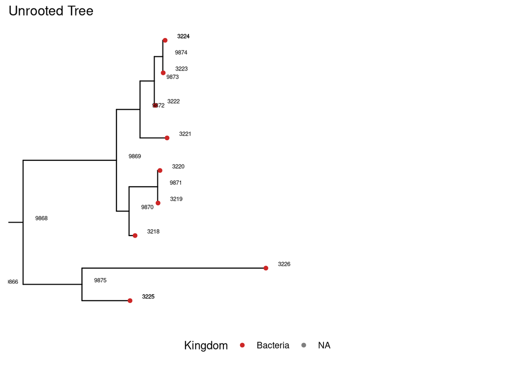

```r
# Let's evaluate!!
viewClade(kingdom_node_tree, 9868) # even more zoomed out
```

In the subtree above, it’s clear that 3226 is longer than the other branches. Let’s inspect some more!

```r
# Or if there are two nodes that we can see we can find its MRCA
## create tibble of tree to identify offspring
tree_tib <- as_tibble(unrooted_physeq@phy_tree)

# Inspect
head(tree_tib)
```

```
## # A tibble: 6 × 4
##   parent  node branch.length label
##    <int> <int>         <dbl> <chr>
## 1   6637     1       0.00676 ASV_4279
## 2   6637     2       0.0142  ASV_4660
## 3   6640     3       0.00055 ASV_2990
## 4   6640     4       0.00274 ASV_6253
## 5   6641     5       0.0600  ASV_4167
## 6   6641     6       0.0213  ASV_5434
```

```r
str(tree_tib)
```

```
## tbl_tree [13,262 × 4] (S3: tbl_tree/tbl_df/tbl/data.frame)
##  $ parent       : int [1:13262] 6637 6637 6640 6640 6641 6641 6642 6643 6643 6644 ...
##  $ node         : int [1:13262] 1 2 3 4 5 6 7 8 9 10 ...
##  $ branch.length: num [1:13262] 0.00676 0.01416 0.00055 0.00274 0.05995 ...
##  $ label        : chr [1:13262] "ASV_4279" "ASV_4660" "ASV_2990" "ASV_6253" ...
```

```r
# lets look at the long branch
mrca_node_3226 <- tidytree::MRCA(unrooted_tree, .node1 = 3226, .node2 = 3225) #9875

# Inspect
mrca_node_3226
```

```
## [1] 9875
```

```r
## create dataframe to view ASVs and taxa info and to pull the ASVs
node_9875 <-
  offspring(tree_tib, mrca_node_3226, tiponly = TRUE) %>%
  as.data.frame() %>%
  pull(label)

# Inspect
node_9875
```

```
## [1] "ASV_3749" "ASV_6240"
```

```r
# Now, let's pull out the taxonomy information, including the ASV sequence!
node_9875_df <-
  unrooted_physeq %>%
  tax_table() %>%
  as.data.frame() %>%
  filter(ASV %in% node_9875)

# Take a look:
glimpse(node_9875_df)
```

```
## Rows: 2
## Columns: 9
## $ Kingdom <chr> "Bacteria", "Bacteria"
## $ Phylum  <chr> "Bacteroidota", "Bacteroidota"
## $ Class   <chr> "Bacteroidia", "Bacteroidia"
## $ Order   <chr> "Chitinophagales", "Chitinophagales"
## $ Family  <chr> NA, NA
## $ Genus   <chr> NA, NA
## $ Species <chr> NA, NA
## $ ASV     <chr> "ASV_3749", "ASV_6240"
## $ ASVseqs <chr> "TAAGGAATATTGGTCAATGGGGGAAACCCTGAACCAGCTATCCCGCGTGCAGGATGAATGC…
```

```r
# look at counts of the ASVs
unrooted_physeq %>%
  subset_taxa(., ASV %in% node_9875_df$ASV) %>%
  otu_table() %>%
  data.frame() %>%
  colSums()
```

```
## X16S0064C X16S0064W X16S0073C X16S0073O X16S0073W X16S0074C X16S0074O X16S0084C
##         0         0         0         0         0         0         0         0
## X16S0084W X16S0087C X16S0087O X16S0088C X16S0088O X16S0089C X16S0089O X16S0090C
##         0         0         0         0         0         0         0         0
## X16S0090O X16S0092C X16S0093C X16S0093O X16S0093W X16S0094C X16S0113O X16S0117C
##         0         0         0         0         0         0         0         0
## X16S0117O X16S0117W X16S0118C X16S0119C X16S0119O X16S0119W X16S0120C X16S0120O
##         0         6         0         0         0         0         0         0
## X16S0120W X16S0123C X16S0123O X16S0123W X16S0141C X16S0141O X16S0142C X16S0142O
##         0         0         0         0         0        19         0         0
## X16S0143C X16S0143O X16S0146C X16S0146O
##         0         4         0         0
```

```r
# Lets BLAST our sequences to investigate if they are real or not
node_9875_df
```

```
##           Kingdom       Phylum       Class           Order Family Genus Species
## ASV_3749 Bacteria Bacteroidota Bacteroidia Chitinophagales   <NA>  <NA>    <NA>
## ASV_6240 Bacteria Bacteroidota Bacteroidia Chitinophagales   <NA>  <NA>    <NA>
##               ASV
## ASV_3749 ASV_3749
## ASV_6240 ASV_6240
##                                                                                                                                                                                                                                                                                                          …
## ASV_3749 TAAGGAATATTGGTCAATGGGGGAAACCCTGAACCAGCTATCCCGCGTGCAGGATGAATG…
## ASV_6240  TAAGGAATATTGGTCAATGGGGGCAACCCTGAACCAGCCATGCCGCGTGGAGGAAGACGG…
```

`ASV_3749` and `ASV_6240` have 29 counts across 3 sample.

# BLAST

#### The BLAST results:

Both `ASV_3749` and `ASV_6240` have the same top hit: an uncultured bacterium from a tropical water biofilm with the project title “Bacteria communities from tropical biofilm.” Both have good alignments. - `ASV_3749`: - **E-value:** 0 - **% Identity:** 98.82% - `ASV_6240`: - **E-value:** 9e-128 - **% Identity:** 86.79%

This seems legit!

### Evaluate node #12810

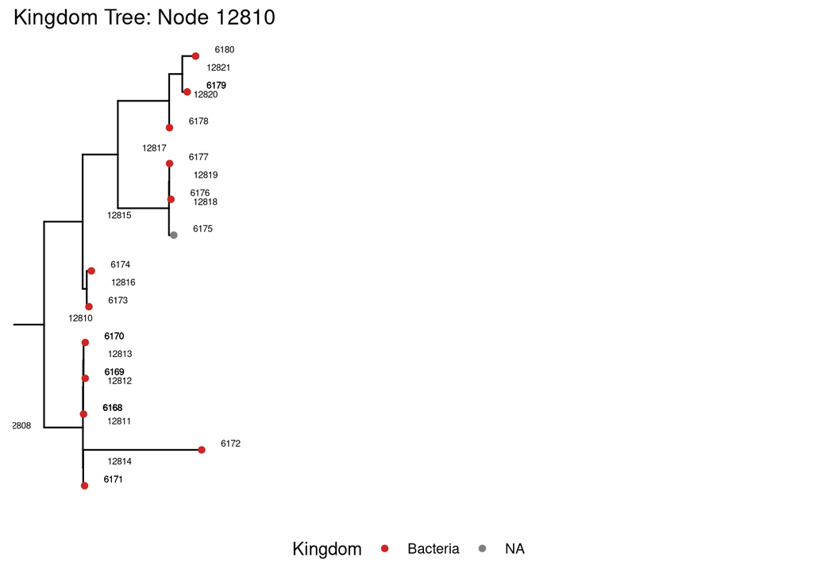

```r
# View a specific clade
# Zoom in on node that looks potentially suspicious
viewClade(kingdom_node_tree +
          labs(title = "Kingdom Tree: Node 12810"),
          node = 12810)
```

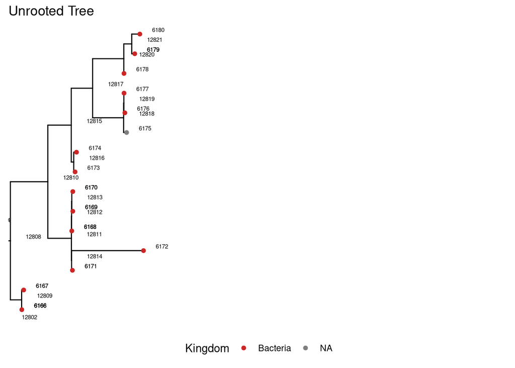

```r
#6172 looks a little sus

# Let's evaluate !!
viewClade(kingdom_node_tree, 12808) # even more zoomed out
```

In the subtree above, it’s clear that 6172 is longer than the other branches. Let’s inspect some more!

```r
# lets look at the long branch
# Filter the rows where node is 6172
node_6172_row <- tree_tib %>%
  filter(node == 6172)

# Inspect the result - node 6172 has ASV_2602 and parent 12814
print(node_6172_row)
```

```
## # A tibble: 1 × 4
##   parent  node branch.length label
##    <int> <int>         <dbl> <chr>
## 1  12814  6172         0.202 ASV_2602
```

```r
# Now, let's pull out the taxonomy information, including the ASV sequence!
node_6172_df <-
  unrooted_physeq %>%
  tax_table() %>%
  as.data.frame() %>%
  filter(ASV == "ASV_2602")

# Take a look:
glimpse(node_6172_df)
```

```
## Rows: 1
## Columns: 9
## $ Kingdom <chr> "Bacteria"
## $ Phylum  <chr> "Pseudomonadota"
## $ Class   <chr> "Gammaproteobacteria"
## $ Order   <chr> "Enterobacterales"
## $ Family  <chr> "Pasteurellaceae"
## $ Genus   <chr> NA
## $ Species <chr> NA
## $ ASV     <chr> "ASV_2602"
## $ ASVseqs <chr> "TGAGGAATATTGGTCAATGGGCAAATGCCTGAACCAGCCAAGTCGCGTGAAGGATGACTGC…
```

```r
# look at counts of the ASVs
unrooted_physeq %>%
  subset_taxa(., ASV == "ASV_2602") %>%
  otu_table() %>%
  data.frame() %>%
  colSums()
```

```
## X16S0064C X16S0064W X16S0073C X16S0073O X16S0073W X16S0074C X16S0074O X16S0084C
##         0         0         0         0         0        63         0         0
## X16S0084W X16S0087C X16S0087O X16S0088C X16S0088O X16S0089C X16S0089O X16S0090C
##         0         0         0         0         0         0         0         0
## X16S0090O X16S0092C X16S0093C X16S0093O X16S0093W X16S0094C X16S0113O X16S0117C
##         0         0         0         0         0         0         0         0
## X16S0117O X16S0117W X16S0118C X16S0119C X16S0119O X16S0119W X16S0120C X16S0120O
##         0         0         0         0         0         0         0         0
## X16S0120W X16S0123C X16S0123O X16S0123W X16S0141C X16S0141O X16S0142C X16S0142O
##         0         0         0         0         0         0         0         0
## X16S0143C X16S0143O X16S0146C X16S0146O
##         0         0         0         0
```

```r
# What other organisms are nearby?
# Find MRCA
mrca_node_6172 <- tidytree::MRCA(unrooted_tree, .node1 = 6172, .node2 = 6171) #12814

# Inspect
mrca_node_6172
```

```
## [1] 12814
```

```r
## create dataframe to view ASVs and taxa info and to pull the ASVs
node_12814 <-
  offspring(tree_tib, mrca_node_6172, tiponly = TRUE) %>%
  as.data.frame() %>%
  pull(label)

# Inspect
node_12814
```

```
## [1] "ASV_0052" "ASV_2602"
```

```r
# Now, let's pull out the taxonomy information, including the ASV sequence!
node_12814_df <-
  unrooted_physeq %>%
  tax_table() %>%
  as.data.frame() %>%
  filter(ASV %in% node_12814)

# Take a look:
glimpse(node_12814_df)
```

```
## Rows: 2
## Columns: 9
## $ Kingdom <chr> "Bacteria", "Bacteria"
## $ Phylum  <chr> "Pseudomonadota", "Pseudomonadota"
## $ Class   <chr> "Gammaproteobacteria", "Gammaproteobacteria"
## $ Order   <chr> "Enterobacterales", "Enterobacterales"
## $ Family  <chr> "Pasteurellaceae", "Pasteurellaceae"
## $ Genus   <chr> NA, NA
## $ Species <chr> NA, NA
## $ ASV     <chr> "ASV_0052", "ASV_2602"
## $ ASVseqs <chr> "TGGGGAATATTGCGCAATGGGGGGAACCCTGACGCAGCCATGCCGCGTGAATGAAGAAGGC…
```

```r
# look at counts of the ASVs
unrooted_physeq %>%
  subset_taxa(., ASV %in% node_12814_df$ASV) %>%
  otu_table() %>%
  data.frame() %>%
  colSums()
```

```
## X16S0064C X16S0064W X16S0073C X16S0073O X16S0073W X16S0074C X16S0074O X16S0084C
##         0         0         0         0         0     16088         0         0
## X16S0084W X16S0087C X16S0087O X16S0088C X16S0088O X16S0089C X16S0089O X16S0090C
##         0         0         0         0         0         0         0         0
## X16S0090O X16S0092C X16S0093C X16S0093O X16S0093W X16S0094C X16S0113O X16S0117C
##         0      1148         0         0         0         0         0         0
## X16S0117O X16S0117W X16S0118C X16S0119C X16S0119O X16S0119W X16S0120C X16S0120O
##         0         0         0         0         0         0         0         0
## X16S0120W X16S0123C X16S0123O X16S0123W X16S0141C X16S0141O X16S0142C X16S0142O
##         0         0         0         0         0         0         0         0
## X16S0143C X16S0143O X16S0146C X16S0146O
##         0         0         0         0
```

```r
# Lets BLAST our sequences to investigate if they are real or not
node_12814_df
```

```
##           Kingdom         Phylum               Class            Order
## ASV_0052 Bacteria Pseudomonadota Gammaproteobacteria Enterobacterales
## ASV_2602 Bacteria Pseudomonadota Gammaproteobacteria Enterobacterales
##                   Family Genus Species      ASV
## ASV_0052 Pasteurellaceae  <NA>    <NA> ASV_0052
## ASV_2602 Pasteurellaceae  <NA>    <NA> ASV_2602
##                                                                                                                                                                                                                                                                                                          …
## ASV_0052 TGGGGAATATTGCGCAATGGGGGGAACCCTGACGCAGCCATGCCGCGTGAATGAAGAAGG…
## ASV_2602      TGAGGAATATTGGTCAATGGGCAAATGCCTGAACCAGCCAAGTCGCGTGAAGGATGACTG…
```

`ASV_0052` and `ASV_2602` have 17236 across 2 samples. `ASV_2602` has 63 counts across 1 sample, a much smaller portion!

Both `ASV_0052` and `ASV_2602` belong to the Family Pasteurellaceae, and don’t have genus/species designations.

# BLAST

#### The BLAST results:

- `ASV_0052`: The first hit is Pasteurellaceae bacterium 20215/4 from goose with salpingitis with the project title “Phylogenetic relationships of unclassified, satellitic Pasteurellaceae obtained from different species of birds as demonstrated by 16S rRNA gene sequence comparison.” This is a strong alignment.
  - **Node:** 6171
  - **E-value:** 0
  - **% Identity:** 94.41%
- `ASV_2602`: The first hit is an uncultured bacterium from an aphid microbiome with the project title “Microbiome diversity of Aphis glycines with extensive superinfection in native and invasive populations.” This is a strong alignment.
  - **Node:** 6172
  - **E-value:** 6e-125
  - **% Identity:** 86.99%

Despite the long branch this looks legit!

### Evaluate node #1524

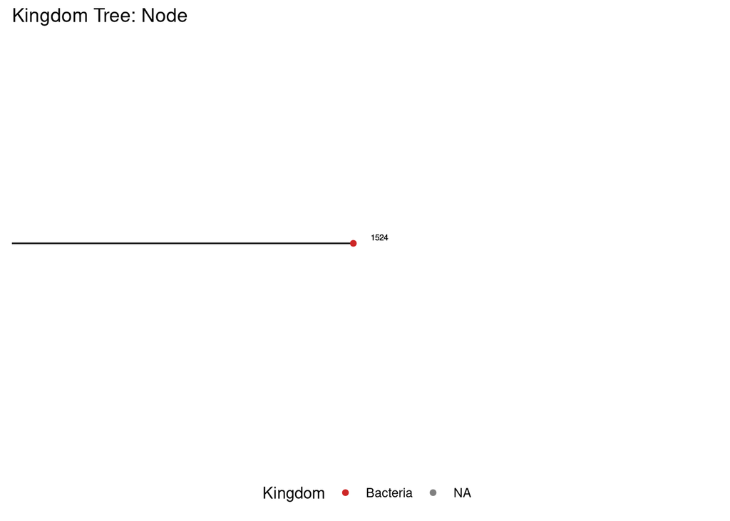

```r
# View a specific clade
# Zoom in on node that looks potentially suspicious
viewClade(kingdom_node_tree +
          labs(title = "Kingdom Tree: Node"),
          node = 1524)
```

```r
# This plot is too zoomed in! Let's try to zoom out by looking at ancestors
# Lets see its ancestors, which will tell us each node as it steps up.
# It's ideal to look a couple nodes up but not too far!
mrca_node_1524 <- tidytree::MRCA(unrooted_tree, .node1 = 1524, .node2 = 1523) #8172
tidytree::ancestor(unrooted_tree, 1524) # The input is the TREE, not phyloseq!!
```

```
##  [1] 8173 8172 8097 8096 8085 8084 8083 7853 7852 7802 7801 7800 7799 7798 7789
## [16] 7786 7609 7608 7607 7606 7514 7223 7071 6984 6952 6951 6873 6872 6866 6865
## [31] 6764 6763 6761 6739 6738 6737 6702 6701 6648 6633
```

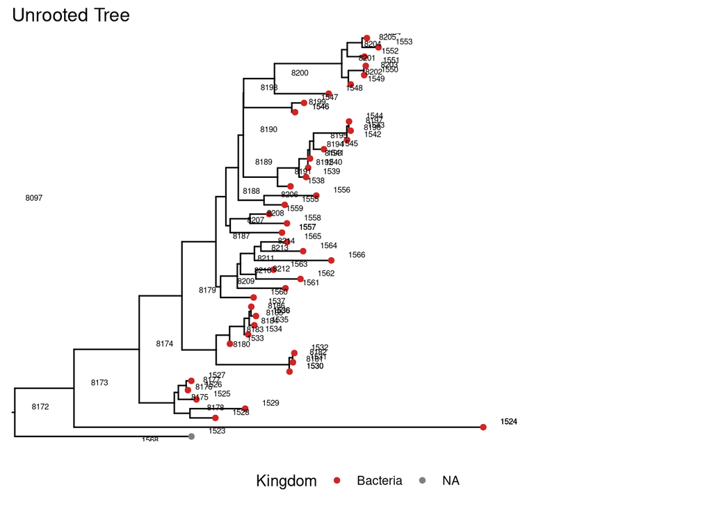

```r
# Let's evaluate !!
viewClade(kingdom_node_tree, 8172) # even more zoomed out
```

In the subtree above, it’s clear that 1524 a long branch. Let’s inspect some more!

```r
# lets look at the long branch
# Filter the rows where node is 1524
node_1524_row <- tree_tib %>%
  filter(node == 1524)

# Inspect the result - node 1524 has ASV_1929 and parent 8173
print(node_1524_row)
```

```
## # A tibble: 1 × 4
##   parent  node branch.length label
##    <int> <int>         <dbl> <chr>
## 1   8173  1524         0.697 ASV_1929
```

```r
# Now, let's pull out the taxonomy information, including the ASV sequence!
node_1524_df <-
  unrooted_physeq %>%
  tax_table() %>%
  as.data.frame() %>%
  filter(ASV == "ASV_1929")

# Take a look:
glimpse(node_1524_df)
```

```
## Rows: 1
## Columns: 9
## $ Kingdom <chr> "Bacteria"
## $ Phylum  <chr> "Patescibacteria"
## $ Class   <chr> "Parcubacteria"
## $ Order   <chr> "Candidatus Moranbacteria"
## $ Family  <chr> NA
## $ Genus   <chr> NA
## $ Species <chr> NA
## $ ASV     <chr> "ASV_1929"
## $ ASVseqs <chr> "TCGAGAATATTTCACAATGGACGAAAGTCTGATGAAGCGACGCTGCGTGCGGGATGAAGGC…
```

```r
# look at counts of the ASVs
unrooted_physeq %>%
  subset_taxa(., ASV == "ASV_1929") %>%
  otu_table() %>%
  data.frame() %>%
  colSums()
```

```
## X16S0064C X16S0064W X16S0073C X16S0073O X16S0073W X16S0074C X16S0074O X16S0084C
##         0         0         0         0         0         0         0         0
## X16S0084W X16S0087C X16S0087O X16S0088C X16S0088O X16S0089C X16S0089O X16S0090C
##         0         0         0         0         0         0         0         0
## X16S0090O X16S0092C X16S0093C X16S0093O X16S0093W X16S0094C X16S0113O X16S0117C
##         0         0         0         0         0         0         0         0
## X16S0117O X16S0117W X16S0118C X16S0119C X16S0119O X16S0119W X16S0120C X16S0120O
##         0         0         0         0       121         0         0         0
## X16S0120W X16S0123C X16S0123O X16S0123W X16S0141C X16S0141O X16S0142C X16S0142O
##         0         0         0         0         0         5         0         0
## X16S0143C X16S0143O X16S0146C X16S0146O
##         0         0         0         0
```

```r
# What other organisms are nearby?
node_8172 <-
  offspring(tree_tib, 8172, tiponly = TRUE) %>%
  as.data.frame() %>%
  pull(label)

node_8172_df <-
  unrooted_physeq %>%
  tax_table() %>%
  as.data.frame() %>%
  filter(ASV %in% node_8172)

glimpse(node_8172_df)
```

```
## Rows: 44
## Columns: 9
## $ Kingdom <chr> "Bacteria", "Bacteria", "Bacteria", "Bacteria", "Bacteria", "B…
## $ Phylum  <chr> "Verrucomicrobiota", "Patescibacteria", "Verrucomicrobiota", "…
## $ Class   <chr> "Verrucomicrobiia", "Parcubacteria", "Verrucomicrobiia", "Verr…
## $ Order   <chr> "Pedosphaerales", "Candidatus Moranbacteria", "Opitutales", "O…
## $ Family  <chr> "Pedosphaeraceae", NA, "Puniceicoccaceae", "Puniceicoccaceae",…
## $ Genus   <chr> "RS25G", NA, "Pelagicoccus", "Pelagicoccus", "Pelagicoccus", "…
## $ Species <chr> NA, NA, NA, NA, NA, NA, NA, NA, NA, NA, NA, NA, NA, NA, NA, NA…
## $ ASV     <chr> "ASV_6374", "ASV_1929", "ASV_5123", "ASV_1697", "ASV_3506", "A…
## $ ASVseqs <chr> "TCGAGAATTTTTCACAATGGGCGCAAGCCTGATGGAGCGACGCCGCGTGGGGGATGAAGGG…
```

```r
unrooted_physeq %>%
  subset_taxa(., ASV %in% node_8172_df$ASV) %>%
  otu_table() %>%
  data.frame() %>%
  colSums()
```

```
## X16S0064C X16S0064W X16S0073C X16S0073O X16S0073W X16S0074C X16S0074O X16S0084C
##         0        12         0         0        10         0        11         0
## X16S0084W X16S0087C X16S0087O X16S0088C X16S0088O X16S0089C X16S0089O X16S0090C
##       582         0         0         0         0         3         4         0
## X16S0090O X16S0092C X16S0093C X16S0093O X16S0093W X16S0094C X16S0113O X16S0117C
##        22         0         0        19         0         0        10         0
## X16S0117O X16S0117W X16S0118C X16S0119C X16S0119O X16S0119W X16S0120C X16S0120O
##        21        31         4         0       994         0         0        15
## X16S0120W X16S0123C X16S0123O X16S0123W X16S0141C X16S0141O X16S0142C X16S0142O
##         0         0         0         0         0        23         9         0
## X16S0143C X16S0143O X16S0146C X16S0146O
##         0         6         6         0
```

```r
node_8172_df
```

```
##           Kingdom            Phylum            Class                    Order
## ASV_6374 Bacteria Verrucomicrobiota Verrucomicrobiia           Pedosphaerales
## ASV_1929 Bacteria   Patescibacteria    Parcubacteria Candidatus Moranbacteria
## ASV_5123 Bacteria Verrucomicrobiota Verrucomicrobiia               Opitutales
## ASV_1697 Bacteria Verrucomicrobiota Verrucomicrobiia               Opitutales
## ASV_3506 Bacteria Verrucomicrobiota Verrucomicrobiia               Opitutales
## ASV_3757 Bacteria Verrucomicrobiota Verrucomicrobiia               Opitutales
## ASV_5907 Bacteria Verrucomicrobiota Verrucomicrobiia               Opitutales
## ASV_5479 Bacteria Verrucomicrobiota Verrucomicrobiia               Opitutales
## ASV_4473 Bacteria Verrucomicrobiota Verrucomicrobiia               Opitutales
## ASV_6010 Bacteria Verrucomicrobiota Verrucomicrobiia               Opitutales
## ASV_5995 Bacteria Verrucomicrobiota Verrucomicrobiia               Opitutales
## ASV_5790 Bacteria Verrucomicrobiota Verrucomicrobiia               Opitutales
## ASV_2780 Bacteria Verrucomicrobiota Verrucomicrobiia               Opitutales
## ASV_1830 Bacteria Verrucomicrobiota Verrucomicrobiia               Opitutales
## ASV_4202 Bacteria Verrucomicrobiota Verrucomicrobiia               Opitutales
## ASV_2587 Bacteria Verrucomicrobiota Verrucomicrobiia               Opitutales
## ASV_4996 Bacteria Verrucomicrobiota Verrucomicrobiia               Opitutales
## ASV_4454 Bacteria Verrucomicrobiota Verrucomicrobiia               Opitutales
## ASV_3989 Bacteria Verrucomicrobiota Verrucomicrobiia               Opitutales
## ASV_3826 Bacteria Verrucomicrobiota Verrucomicrobiia               Opitutales
## ASV_5269 Bacteria Verrucomicrobiota Verrucomicrobiia               Opitutales
## ASV_5794 Bacteria Verrucomicrobiota Verrucomicrobiia               Opitutales
## ASV_5308 Bacteria Verrucomicrobiota Verrucomicrobiia               Opitutales
## ASV_4646 Bacteria Verrucomicrobiota Verrucomicrobiia               Opitutales
## ASV_6218 Bacteria Verrucomicrobiota Verrucomicrobiia               Opitutales
## ASV_6127 Bacteria Verrucomicrobiota Verrucomicrobiia               Opitutales
## ASV_4327 Bacteria Verrucomicrobiota Verrucomicrobiia               Opitutales
## ASV_1548 Bacteria Verrucomicrobiota Verrucomicrobiia               Opitutales
## ASV_2281 Bacteria Verrucomicrobiota Verrucomicrobiia               Opitutales
## ASV_3410 Bacteria Verrucomicrobiota Verrucomicrobiia               Opitutales
## ASV_1889 Bacteria Verrucomicrobiota Verrucomicrobiia               Opitutales
## ASV_3199 Bacteria Verrucomicrobiota Verrucomicrobiia               Opitutales
## ASV_4293 Bacteria Verrucomicrobiota Verrucomicrobiia               Opitutales
## ASV_5855 Bacteria Verrucomicrobiota Verrucomicrobiia               Opitutales
## ASV_3883 Bacteria Verrucomicrobiota Verrucomicrobiia               Opitutales
## ASV_5462 Bacteria Verrucomicrobiota Verrucomicrobiia               Opitutales
## ASV_5839 Bacteria Verrucomicrobiota Verrucomicrobiia               Opitutales
## ASV_6047 Bacteria Verrucomicrobiota Verrucomicrobiia               Opitutales
## ASV_6388 Bacteria Verrucomicrobiota Verrucomicrobiia               Opitutales
```

[output cut: 80 more lines]

```
## ASV_3410      TTTCGAATCATTCACAATGGGCGAAAGCCTGATGATGCAATGCCGCGTGGAGGATGAAGG…
## ASV_1889      TTTCGAATCATTCACAATGGGCGAAAGCCTGATGATGCAATGCCGCGTGGAGGATGACGG…
## ASV_3199      TTTCGAATCATTCACAATGGGCGAAAGCCTGATGATGCAATGCCGCGTGGAGGATGAAGG…
## ASV_4293      TTTCGAATCATCCACAATGGGCGAAAGCCTGATGGTGCGACGTCGCGTGGGGGATGAAGG…
## ASV_5855      TTTCGAATCATTCACAATGGGCGAAAGCCTGATGATGCAACGCCGCGTGGGGGATGACGG…
## ASV_3883      TTTCGAATCATTCACAATGGGCGCAAGCCTGATGGTGCAATGCCGCGTGGGGGATGACGG…
## ASV_5462      TTTCGAATCATTCACAATGGGCGAAAGCCTGATGGTGCAATGCCGCGTGGGGGATGAAGG…
## ASV_5839      TTTCGAATCATTCACAATGGGCGAAAGCCTGATGGTGCAATGCCGCGTGGGGGATGACGG…
## ASV_6047      TTTCGAATCATTCACAATGGGCGAAAGCCTGATGGTGCGACGTCGCGTGGGGGACGAAGG…
## ASV_6388      TTTCGAATCATTCACAATGGGGGAAACCCTGATGGTGCGACGTCGCGTGGGGGATGAAGG…
## ASV_1116      TTTCGAATCATTCACAATGGGCGCAAGCCTGATGATGCAACGCCGCGTGGGGGACGAAGG…
## ASV_3919      TTTCGAATCATTCACAATGGGCGAAAGCCTGATGGTGCAACGCCGCGTGGGGGATGACGG…
## ASV_6070      TTTCGAATCCTTCACAATGGGCGAAAGCCTGATGGTGCGACGTCGCGTGGGGGATGACGG…
## ASV_6149      TTTCGAATCATCCACAATGGGCGAAAGCCTGATGGTGCGACGTCGCGTGGGGGATGAAGG…
## ASV_6224      TTTCGAATCATTCACAATGGGCGAAAGCCTGATGGTGCGACGTCGCGTGAGGGATGAAGG…
```

```r
# Lets BLAST our sequences to investigate if they are real or not
node_1524_df
```

```
##           Kingdom          Phylum         Class                    Order Family
## ASV_1929 Bacteria Patescibacteria Parcubacteria Candidatus Moranbacteria   <NA>
##          Genus Species      ASV
## ASV_1929  <NA>    <NA> ASV_1929
##                                                                                                                                                                                                                                                                                                          …
## ASV_1929 TCGAGAATATTTCACAATGGACGAAAGTCTGATGAAGCGACGCTGCGTGCGGGATGAAGG…
```

`ASV_1929` has 126 counts across 2 samples.

The ASV for node **#1524** only goes to Order level: **Candidatus Moranbacteria**. All the other ASVs in clade **#8173** have the Order **Opitutales**. The ASV for node **#1524** also belongs to a different phylum than the branches in clade **#8172**: **Patescibacteria** for #1524, **Verrucomicrobiota** for the others.

# BLAST

#### The BLAST results:

- `ASV_1929`: The first hit is an uncultured bacterium from the Nile Deep Sea fan with the project title “Biogeochemistry and community composition of iron- and sulfur-precipitating microbial mats at the Chefren mud volcano.” This is a very strong alignment.
  - **Node:** #1524
  - **E-value:** 4e-121
  - **% Identity:** 86.52%
- `ASV_6374`: The first hit is an uncultured bacterium from rapid sand filter material of groundwater treatment for drinking water production with the project title “Internal porosity of mineral coating supports microbial activity in rapid sand filters for groundwater treatment.” This is a very strong aligment.
  - **Node:** #1523
  - **E-value:** 4e-151
  - **% Identity:** 89.95%
- `ASV_3757`: The first hit is Uncultured Pelagicoccus sp. from the petroleum-contaminated saline-alkali soil with the project title “Bacterial diversity in petroleum-contaminated saline-alkali soil.” This is a very strong alignment.
  - **Node:** #1528
  - **E-value:** 0
  - **% Identity:** 96.95%
- `ASV_5794`: The first hit is an uncultured microorganism from a marine biofilm with the project title “Microbial diversity in marine biofilms along a water quality gradient on the Great Barrier Reef.” This is a very strong alignment.
  - **Node:** #1544
  - **E-value:** 0
  - **% Identity:** 99.29%

`ASV_1929` and `ASV_6374` are likely real ASVs. We will keep these for now.

## 4b. Prune your tree

Our sus branches look like they correcpond to real ASVs, we don’t have to prune any branches for now!

Interpretation 2: There were some long branches in my unrooted tree. I decided not to remove any ASVs since the BLAST alignments were very very strong (the ASVs are most likely real).

# 5. Root the Tree

*What does it mean to root a tree, you ask?* **Rooting a tree** means designating a specific node in a phylogenetic tree as the common ancestor of all other nodes. This establishes a direction of evolution — from the root (the oldest ancestor) to the tips (the current taxa or sequences). A tree without a root is called **unrooted**, and it only shows relationships (like how closely related things are), not the direction of descent.

## Why do we root trees in microbial community analyses?

In microbial ecology, rooted trees are especially useful for:

1. **Calculating Phylogenetic Diversity Metrics**: Metrics like Faith’s Phylogenetic Diversity and the UniFrac distances require a rooted tree to calculate how much evolutionary history is shared between communities. Without a root, the distances between taxa don’t make biological sense in terms of lineage or shared ancestry.
2. **Comparing Community Structure:** Rooting allows you to identify lineages that dominate or are lost between samples, trace evolutionary shifts in microbial composition, interpret ecological or functional patterns across a gradient (*e.g.,* salinity, pH, antibiotic exposure).
3. **Biological Interpretation** Rooted trees are required for the following interpretations, which microbial community ecologists often want to know:
   - *Are these microbes derived from a common ancestor?*
   - *Do the samples diverge from a known lineage (e.g., Proteobacteria)*?
   - *What’s the evolutionary placement of unknown organisms?*

## Methods of Rooting Trees

So, **how do we root a tree**? There are two different types of methods to root a tree:

1. **Outgroup rooting:** Choose a known lineage outside your group of interest (*e.g.,* Archaea as outgroup to Bacteria). *This is always preferred when we have a known outgroup!*
   - *Pros:*
     - Biologically meaningful — places the root based on known evolutionary relationships.
     - More accurate if your outgroup is correctly chosen and aligns well.
     - **Best for:** Hypothesis-driven studies, evolutionary interpretations, or when your dataset includes taxa from multiple domains/phyla.
   - *Cons:*
     - Requires a reliable outgroup — too distant, and it can distort the tree (long-branch attraction).
     - Not always available or appropriate (e.g., if you’re only analyzing a subset of taxa without known outgroups).
2. **Midpoint rooting:** Places the root at the midpoint of the longest path in the tree (useful when no clear outgroup exists).
   - *Pros:*
     - Simple and automatic — no need for prior biological knowledge.
     - Works well for diverse microbial datasets where outgroup info is unclear or unavailable.
     - **Best for**: Exploratory analyses, diversity metrics (like UniFrac), or when working with just bacteria/just archaea and you don’t have a good outgroup.
   - *Cons:*
     - Assumes a molecular clock — that all lineages evolve at similar rates.
     - Can misplace the root if there’s rate variation across branches.

## 5b. Midpoint Root

*If you have Archaea or a clear outgroup, always use the outgroup rooting. If not, you can midpoint root.*

As mentioned above, if your project’s data does not have Archaea or a specified outgroup, it is possible to midpoint root the tree. Midpoint rooting calculates tip to tip distances and then places the root halfway between the two longest tips. This is why it is important to **first prune your tree of contaminating lineages!** If contaminating lineages are included in the midrooting of the tree, then it will throw off the branch lengths.

**Before midrooting the tree:**

1. Investigate and pull the ASVs in your long branches and BLAST to confirm if these are real bacterial ASVs, as mentioned above in the “long branches” section.
2. Remove any unwanted ASVs using the prune function. **Long nodes (branches) are outliers**! If we keep them in the tree, bias will be introduced into the tree reconstruction creating the **long branch attraction** error where distantly related taxa appear closely related due to a high rate of evolution on long branches.

If you **do not** have Archaea and **have** removed your long branches, then you may follow the code below to midroot your tree.

### 6b. Merge phyloseq: Midpoint Rooted Tree

```r
# Check to see if tree is rooted.. expect it to be false
is.rooted(phy_tree(unrooted_physeq))
```

```
## [1] FALSE
```

```r
# Let's midpoint root the tree
midpoint_rooted_tree <-
  unrooted_physeq %>%
  phy_tree() %>%
  phytools::midpoint.root()

# Is the new tree rooted? Should be TRUE!
is.rooted(midpoint_rooted_tree)
```

```
## [1] TRUE
```

```r
# Assign to a new phyloseq object!
# Merge tree with the raw_preprocessed physeq
midpoint_rooted_physeq <-
  merge_phyloseq(raw_preprocessed_physeq, midpoint_rooted_tree)
```

Now, we have a merged phyloseq object! Let’s take a look at what it looks like.

### Plot Midpoint Rooted Tree

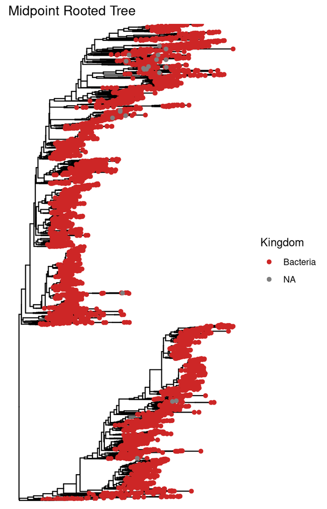

```r
# Quick inspection of tree
midpoint_rooted_tree_plot <-
  ggtree(midpoint_rooted_physeq) +
  geom_tippoint(mapping = aes(color = Kingdom)) +
  geom_tippoint(aes(color = Kingdom)) +
  labs(title = "Midpoint Rooted Tree") +
  scale_color_manual(values = c("firebrick3", "cornflowerblue", "grey"))

# Look at the tree
midpoint_rooted_tree_plot
```

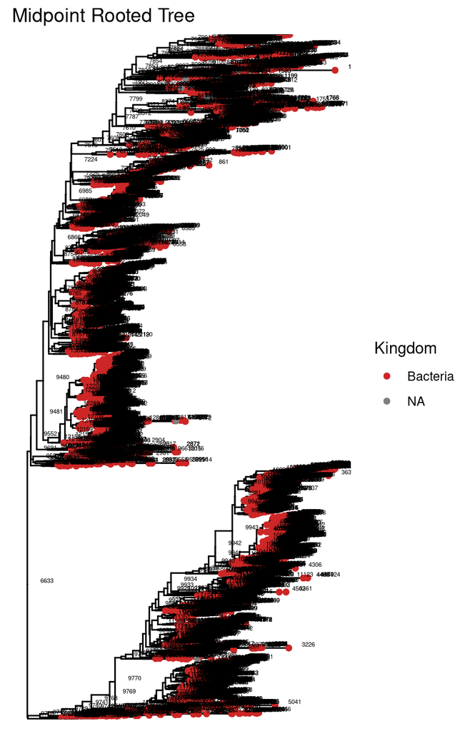

```r
# Add nodes
midpoint_rooted_tree_node_plot <-
  midpoint_rooted_tree_plot +
  geom_text(aes(label = node), hjust = -1, vjust = -0.3, size = 1.5)

# View it
midpoint_rooted_tree_node_plot
```

Interpretation 3: This tree seems finalized. The long branches I have already inspected and determined to be real.

## 7. Save phyloseq objects

### Save individual phyloseq objects

Here, we will create one file that will have a single phyloseq object. This is useful if we only want to work with one tree.

```r
# Now, save midpoint rooted phyloseq object
save(midpoint_rooted_physeq,
     file = "data/04_PhylogeneticTree/midpoint_rooted_physeq.RData")
```

Now that we have our rooted trees inside of a phyloseq object, we can go forth and begin our next analysis!

# Final info for Reproducibility

## Check Render Time

```r
# Take the time now that we are at the end of the script
end_time <- Sys.time()
end_time
```

```
## [1] "2025-03-31 18:55:20 EDT"
```

```r
# Echo the elapsed time
elapsed_time <- round((end_time - start_time), 3)
elapsed_time
```

```
## Time difference of 48.852 secs
```